[figure not shown]

# Lecture 6 - Linear Regression, Multiple Linear Regression, ANOVA, ANCOVA: Choosing the Best Model for the Job

## Student Name: Live HTML

## Student ID:

| Image courtesy of [XKCD](https://xkcd.com/1725/) |
| --- |

| Sometimes plots can be confusing to extrapolate data from! |
| --- |

## 0.1.0 About Introduction to R

Introduction to R is brought to you by the **Centre for the Analysis of Genome Evolution & Function (CAGEF)** bioinformatics training initiative. This course was developed based on feedback on the needs and interests of the Department of Cell & Systems Biology and the Department of Ecology and Evolutionary Biology.

The structure of this course is a code-along style; It is 100% hands on! A few hours prior to each lecture, links to the materials will be available for download at [QUERCUS](https://q.utoronto.ca/). The teaching materials will consist of a Jupyter Notebook with concepts, comments, instructions, and blank coding spaces that you will fill out with R by coding along with the instructor. Other teaching materials include a live-updating HTML version of the notebook, and datasets to import into R - when required. This learning approach will allow you to spend the time coding and not taking notes!

As we go along, there will be some in-class challenge questions for you to solve either individually or in cooperation with your peers. Post lecture assessments will also be available (see syllabus for grading scheme and percentages of the final mark) through [DataCamp](https://Datacamp.com) to help cement and/or extend what you learn each week.

### 0.1.1 Where is this course headed?

We'll take a blank slate approach here to R and assume that you pretty much know *nothing* about programming. From the beginning of this course to the end, we want to take you from some potential scenarios such as...

- A pile of data (like an excel file or tab-separated file) full of experimental observations and you don't know what to do with it.
- Maybe you're manipulating large tables all in excel, making custom formulas and pivot tables with graphs. Now you have to repeat similar experiments and do the analysis again.
- You're generating high-throughput data and there aren't any bioinformaticians around to help you sort it out.
- You heard about R and what it *could* do for your data analysis but don't know what that means or where to start.

and get you to a point where you can...

- Format your data correctly for analysis
- Produce basic plots and perform exploratory analysis
- Make functions and scripts for re-analysing existing or new data sets
- Track your experiments in a digital notebook like Jupyter!

[figure not shown]

### 0.1.2 How do we get there? Step-by-step.

In the first lesson, we will talk about the basic data structures and objects in R, get cozy with the Jupyter Notebook environment, and learn how to get help when you are stuck because everyone gets stuck - a lot! Then you will learn how to get your data in and out of R, how to tidy our data (data wrangling), and then subset and merge data. After that, we will dig into the data and learn how to make basic plots for both exploratory data analysis and publication. We'll follow that up with data cleaning and string manipulation; this is really the battleground of coding - getting your data into just the right format where you can analyse it more easily. We'll then spend a lecture digging into the functions available for the statistical anlaysis of your data. Lastly, we will learn about control flow how to write customized functions, which can really save you time and help scale up your analyses.

[figure not shown]

Don't forget, the structure of the class is a **code-along** style: it is fully hands on. At the end of each lecture, the complete notes will be made available in a PDF format through the corresponding Quercus module so you don't have to spend your attention on taking notes.

### 0.1.3 What kind of coding style will we learn?

There is no single path correct from A to B - although some paths may be more elegant, or more efficient than others. With that in mind, the emphasis in this lecture series will be on:

1. **Code simplicity** - learn helpful functions that allow you to focus on understanding the basic tenets of good data wrangling (reformatting) to facilitate quick exploratory data analysis and visualization.
2. **Code readability** - format and comment your code for yourself and others so that even those with minimal experience in R will be able to quickly grasp the overall steps in your code.
3. **Code stability** - while the core R code is relatively stable, behaviours of functions can still change with updates. There are well-developed packages we'll focus on for our analyses. Namely, we'll become more familiar with the `tidyverse` series of packages. This resource is well-maintained by a large community of developers. While not always the "fastest" approach, this additional layer can help ensure your code still runs (somewhat) smoothly later down the road.

## 0.2.0 Class Objectives

This is the sixth in a series of seven lectures. Last lecture we concluded our journey with data wrangling in the world of regular expressions. This week we will again explore that "clean" data that we've learned to generate using the world of statistical models. At the end of this session you will be able to perform simple and multiple linear regression, one- and multi-way analysis of variance (ANOVA) and analysis of covariance (ANCOVA). You will be able to interpret the statistics that come out of this model, be cognizant of the assumptions made by the model, and use F-test and Akaike Information Criterium (AIC) to select the best model for the job.

1. Basic analysis of datasets and their distribution
2. Linear regression models
3. Generalized linear models
4. Review
5. Resources

[figure not shown]

## 0.3.0 A legend for text format in Jupyter markdown

- `Grey background`: Command-line code, R library and function names
- **Bold italics**: Emphasis for important ideas and concepts
- **Bold**: Headers and subheaders
- Blue text: Named or unnamed hyperlinks
- `...` fill in the code here if you are coding along

**Blue box:** A key concept that is being introduced

**Yellow box:** Risk or caution

**Geen boxes:** Recommended reads and resources to learn R

**Red boxes:** A comprehension question which may or may not involve a coding cell. You usually find these at the end of a section.

## 0.4.0 Lecture and data files used in this course

### 0.4.1 Weekly Lecture and skeleton files

Each week, new lesson files will appear within your JupyterHub folders. We are pulling from a GitHub repository using this [Repository git-pull link](https://jupyter.utoronto.ca/hub/user-redirect/git-pull?repo=https%3A%2F%2Fgithub.com%2Fcamok%2F2023-09-IntroR&urlpath=tree%2F2023-09-IntroR%2F). Simply click on the link and it will take you to the University of Toronto JupyterHub. You will need to use your UTORid credentials to complete the login process. From there you will find each week's lecture files in the directory `/2023-09-IntroR/Lecture_XX`. You will find a partially coded `skeleton.ipynb` file as well as all of the data files necessary to run the week's lecture.

Alternatively, you can download the Jupyter Notebook (`.ipynb`) and data files from JupyterHub to your personal computer if you would like to run independently of the JupyterHub.

### 0.4.2 Live-coding HTML page

A live lecture version will be available at [camok.github.io](https://camok.github.io/2023-09.IntroToR/index.html) that will update as the lecture progresses. Be sure to refresh to take a look if you get lost!

### 0.4.3 Post-lecture PDFs and Recordings

As mentioned above, at the end of each lecture there will be a completed version of the lecture code released as a PDF file under the Modules section of Quercus.

### 0.4.4 Data used in this session

The dataset we will use for this lesson is from the Summer Institute in Statistical Genetics (SISG) at the University of Washington's course in Regression and Analysis of Variance by Lurdes Inoue. This lesson uses a lot of material from the [SISG 2016](https://si.biostat.washington.edu/suminst/archives/SISG2016/SM1604) course as well as conceptual material from [Ben Bolker](https://ms.mcmaster.ca/~bolker/). I like this dataset because it has a number of categorical and continuous variables, which allows us to use the same dataset for many models. Also, the variables are familiar (age, BMI, sex, cholesterol), which makes data interpretation easier while we are in the learning stage.

We'll read the data in and take a look at the structure.

### 0.4.4.1 Dataset 1: SISG-Data-cholesterol.txt

A space-separated file consisting of measurements related to lipid health and haplotype data for variants at loci that may influence these values. We'll be using this dataset to explore and model relationships between genotype and phenotype.

## 0.5.0 Packages used in this lesson

The following packages are used in this lesson:

- `tidyverse` (tidyverse installs several packages for you, like `dplyr`, `readr`, `readxl`, `tibble`, and `ggplot2`). In particular we will be taking advantage of the `stringr` package this week.
- `car` a companion to applied regression which has helpful tools for the analysis of variance.
- `gee` a generalized estimation equation solver for fitting your data.
- `multcomp` general linear hypothesis testing in parametric models.
- `broom` useful for formatting model output from linear models.

Some of these packages should already be installed into your Anaconda base from previous lectures. If not, please review that lesson and load these packages. Remember to please install these packages from the `conda-forge` channel of Anaconda. `conda install -c conda-forge r-biocmanager` `BiocManager::install("limma")` `conda install -c conda-forge r-gee` `conda install -c conda-forge r-multcomp`

```r
#--------- Install packages to for today's session ----------#
# install.packages("tidyverse", dependencies = TRUE) # This package should already be installed on Jupyter Hub

# None of these packages are already available on JupyterHub
# devtools::install_version(package = "pbkrtest", version = "0.5.0.1", dependencies = TRUE)
# install.packages("car", dependencies = TRUE) # ~6 minutes to install all dependencies
# install.packages("gee", dependencies = TRUE) # ~ 3 minutes to install all dependencies

#--------- Load packages to for today's session ----------#
library(tidyverse)
library(car)
library(multcomp) # used for glht()
library(gee) # Generalized Estimation Equation Solver for our Appendix section
library(broom)
```

## 0.6.0 A little stats is a dangerous thing: an important aside about this lecture

I am not a statistician and likely have just enough knowledge to realize that I mostly know nothing about statistics. The tools and methods we discuss today are to familiarize you with the concept of creating simple linear models but you should **always** think deeply about your data and approach it with the right statistical toolset.

Before embarking on your journey, ask if your data meets all the criteria for this type of analysis. Read papers on similar subjects and see what the consensus is!

| Don't get trapped on Mount Stupid of the Dunning-Kruger curve! We're aiming for the Valley! To despair... and beyond! |
| --- |

# 1.0.0 Answering questions with data

In order to work with our data we need to be able to answer some basic questions.

- How do we describe our data?
- How do we test our hypotheses (what model do we use)?
- How do we test our assumptions about the model we are using?
- How do we compare models?
- How do we make a prediction with new values?

These are all really important questions that we may or may not think about as we try to dive in and get our answer as quickly as possible. Today we are going to slow down a bit and think about our data and our models.

Let's load our dataset today with a new function, `read.delim()`, where we will specify that the file is space-separated with a header.

**Why use read.delim()?:** Up until now we've mostly stuck to functions supplied from the **readr** package, but we're going back to the base R functions to use **read.delim()** because our data includes row names! If you look closely at the text file, there is one less column header in the first row than the other columns of data in the file. Unfortunately **read_delim()** does not handle this data format correctly whereas **read.delim()** will!

```r
# Load our data with a new function: read.delim
# It will recognize the missing column header and make the first column of data into row names
cholesterol <- read.delim("data/SISG-Data-cholesterol.txt", sep = " ", header=TRUE)

# Check the structure of our data set
str(cholesterol)

# What does it look like
head(cholesterol)
```

```
'data.frame':	400 obs. of  9 variables:
 $ ID       : int  1 2 3 4 5 6 7 8 9 10 ...
 $ sex      : int  1 1 0 0 1 1 0 0 0 0 ...
 $ age      : int  74 51 64 34 52 39 79 38 52 58 ...
 $ chol     : int  215 204 205 182 175 176 159 169 175 189 ...
 $ BMI      : num  26.2 24.7 24.2 23.8 34.1 22.7 22.9 24.9 20.4 22 ...
 $ TG       : int  367 150 213 111 328 53 274 137 125 209 ...
 $ rs174548 : int  1 2 0 1 0 0 2 1 0 0 ...
 $ rs4775401: int  2 1 1 1 0 2 1 1 1 1 ...
 $ APOE     : int  4 4 4 1 1 4 1 1 4 5 ...
```

A data.frame: 6 × 9

|  | ID <int> | sex <int> | age <int> | chol <int> | BMI <dbl> | TG <int> | rs174548 <int> | rs4775401 <int> | APOE <int> |
| --- | --- | --- | --- | --- | --- | --- | --- | --- | --- |
| 1 | 1 | 1 | 74 | 215 | 26.2 | 367 | 1 | 2 | 4 |
| 2 | 2 | 1 | 51 | 204 | 24.7 | 150 | 2 | 1 | 4 |
| 3 | 3 | 0 | 64 | 205 | 24.2 | 213 | 0 | 1 | 4 |
| 4 | 4 | 0 | 34 | 182 | 23.8 | 111 | 1 | 1 | 1 |
| 5 | 5 | 1 | 52 | 175 | 34.1 | 328 | 0 | 0 | 1 |
| 6 | 6 | 1 | 39 | 176 | 22.7 | 53 | 0 | 2 | 4 |

### 1.0.1 A brief breakdown of our data

This dataset maps genetic variants (single nucleotide polymorphisms or SNPs) and their relationship to cholesterol (chol) and triglycerides (TG) for 3 genes: rs174548 (FADS1 - an enzyme in fatty acid unsaturation), rs4775401 (a candidate SNP), and APOE (a major apolipoprotein important for Alzheimer's disease).

| ID | sex | age | chol | BMI | TG | rs174548 | rs4775401 | APOE |
| --- | --- | --- | --- | --- | --- | --- | --- | --- |
| patient code | Male=0 Female=1 | patient age | cholesterol | Body mass index | triglycerides | haplotype C/C = 0 C/G = 1 G/G = 2 | haplotype C/C = 0 C/T = 1 T/T = 2 | allele haplotype e2/e2 = 1 e2/e3 = 2 e2/e4 = 3 e3/e3 = 4 e3/e4 = 5 e4/e4 = 6 |

### 1.0.2 Use exploratory plots to begin identifying relationships in your dataset

We are ultimately interested in the relationship between the above genetic variants and cholesterol, while controlling for factors such as age and sex. But let's get our feet wet by starting with the easier **question: is there an association between mean serum cholesterol and age?**

For this question cholesterol is the **dependent variable**, or the variable being measured. Age is the **independent variable** that we are changing to determine the effect on cholesterol.

It is always, **always**, **always**, a good idea to make an 'exploratory' plot of your data and get an idea of what its distribution looks like. We can start with a simple scatter plot of age and cholesterol.

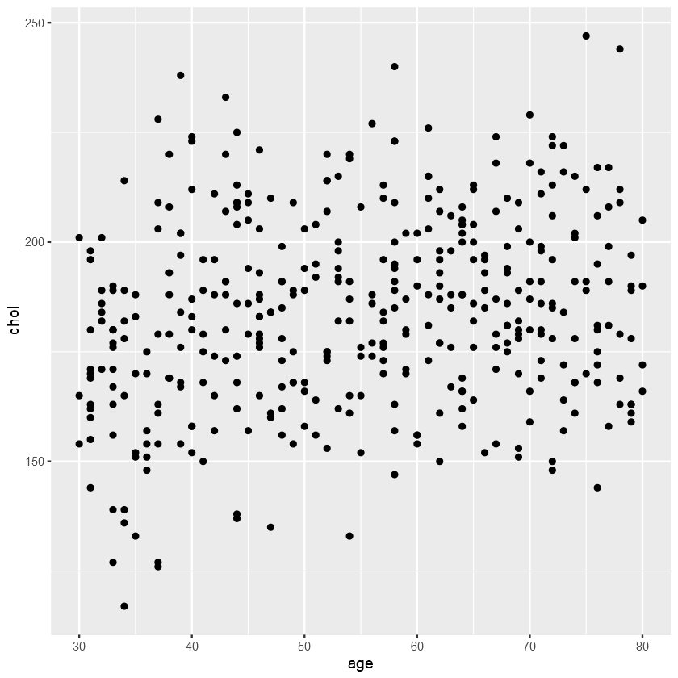

```r
# Plot age vs cholesterol as a scatterplot
# 1. Data
ggplot(cholesterol) +
    # 2. Aesthetics
    aes(x = age, y = chol) +
    # 4. Geoms
    geom_point()
```

### 1.0.3 Generate summary statistics to explore your data

Our data above looks pretty spread out along these axes. Let's generate some summary statistics to explore it further. We can describe our data with some basic summary statistics such as the mean, median, mode, min, max, standard deviation, and variance (central tendency and dispersion measures). R does not have a mode function relating to statistics, but we can figure it out for ourselves.

```r
#Revisit the structure of our data
str(cholesterol)

# Pipe our dataset over to the summarise function (mean, median, min, max, sd, variance)
cholesterol %>%
    summarise(mean_chol = mean(chol),
              median_chol = median(chol),
              min_chol = min(chol),
              max_chol = max(chol),
              sd_chol = sd(chol),
              variance_chol = var(chol))

# We need to calculate mode on our own by sorting
mode <- sort(table(cholesterol$chol), decreasing = TRUE)
# Note: we can't use arrange on the resulting table

# We can access table header information using the names() function
# Then we can concatenate values to a printout with the cat() function
cat("Most frequent chol value is:", names(mode[1]), "with", mode[1], "occurrences") # most frequent value in our dataset
```

```
'data.frame':	400 obs. of  9 variables:
 $ ID       : int  1 2 3 4 5 6 7 8 9 10 ...
 $ sex      : int  1 1 0 0 1 1 0 0 0 0 ...
 $ age      : int  74 51 64 34 52 39 79 38 52 58 ...
 $ chol     : int  215 204 205 182 175 176 159 169 175 189 ...
 $ BMI      : num  26.2 24.7 24.2 23.8 34.1 22.7 22.9 24.9 20.4 22 ...
 $ TG       : int  367 150 213 111 328 53 274 137 125 209 ...
 $ rs174548 : int  1 2 0 1 0 0 2 1 0 0 ...
 $ rs4775401: int  2 1 1 1 0 2 1 1 1 1 ...
 $ APOE     : int  4 4 4 1 1 4 1 1 4 5 ...
```

A data.frame: 1 × 6

| mean_chol <dbl> | median_chol <dbl> | min_chol <int> | max_chol <int> | sd_chol <dbl> | variance_chol <dbl> |
| --- | --- | --- | --- | --- | --- |
| 183.915 | 184 | 117 | 247 | 22.11777 | 489.1958 |

```
Most frequent chol value is: 191 with 12 occurrences
```

**Why is there no "mode" function in R?** Who knows really but I certainly haven't found any indication as to why. Of course there are some [packages that can help do this for you](https://www.rdocumentation.org/packages/DescTools/versions/0.99.46/topics/Mode) but we've used the [**table()** function](https://www.rdocumentation.org/packages/base/versions/3.6.2/topics/table) instead to help us make a frequency table from a vector of values. You can actually use this on a dataframe and it will group by factors you choose (or do not excluded) from conversion. You can also try out the **tabulate()** function but that's more focused on calculating frequency from a vector of integers.

### 1.0.4 Make a density plot with `geom_density` to visualize your sample distribution

Our mean, median and mode are not that different, and so our data is not skewed in either direction. We can also prove this to ourselves by making a quick **density plot** to visualize the residuals (each data point minus the mean)

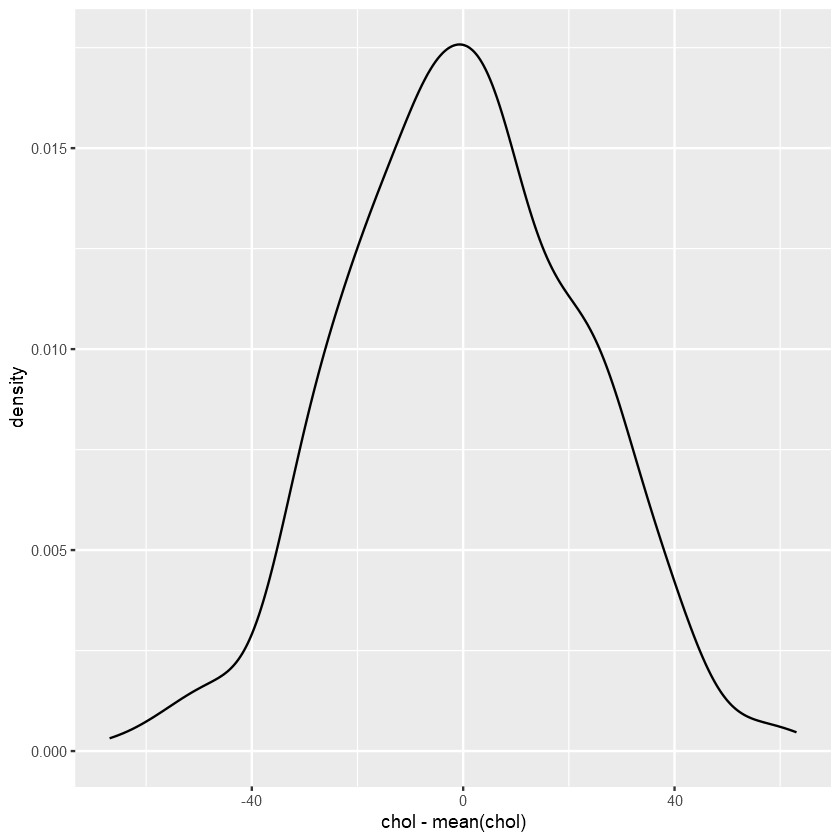

```r
# make a density plot around the mean cholesterol value
# 1. Data
ggplot(cholesterol) +
    # 2. Aesthetics
    aes(x = chol - mean(chol)) + # Subtract the mean from each value to centre the distribution around 0
    # 4. Geoms
    geom_density() # Use a kernel density estimate
```

### 1.0.5 Use `quantile()` to gauge the range of your distribution

Another way to dissect our distribution is by examining the values/boundaries of our dataset when we break it into various portions. We can accomplish the task of breaking up our data using the `quantile()` function. We can set the levels of proportions we want to generate

Using the default behaviour of `quantile()` generates *quartiles* of our data which will also give us a good sense of the range and distribution of our data.

```r
# Use the default quantile parameters
quantile(cholesterol$chol)
```

**0%**

117

**25%**

168

**50%**

184

**75%**

199.25

**100%**

247

### 1.0.6 Is age related to cholesterol?

Going back to our question regarding if age is related to cholesterol, let's add the mean cholesterol to our plot for reference. This is done by adding `geom_hline()` to our plot and specifying the value for the `yintercept`.

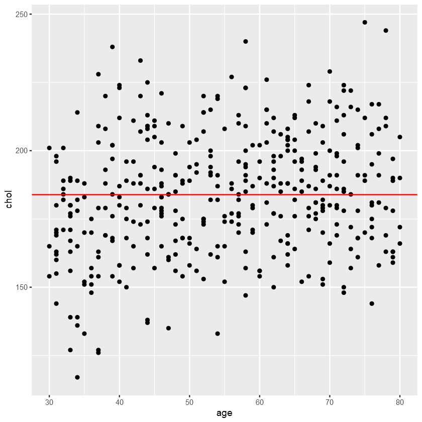

```r
# Modify our scatterplot to include a mean cholesterol value

# 1. Data
ggplot(cholesterol) +
    # 2. Aesthetics
    aes(x = age, y = chol) +
    # 4. Geoms
    geom_point() +                                                  # Add the data points
    geom_hline(yintercept = mean(cholesterol$chol), color = "red")  # Add a simple horizontal line at the mean
```

From our plot, it looks like the mean might increase with age, but how do we test this?

## 1.1.0 Preparing data for a Student's t-test

T-tests are a simple statistical tool to compare pairs of means, **i.e. between two groups at the same time**. We don't currently have age groups, but we can make them. One way to do this is to use our `dplyr` skills to create a new column 'age_group'. The data can be split at 55 years-old (the midpoint of age in our data).

We'll take advantage of creating a conditional and then casting its logical result to numeric values. Recall that you can cast a logical to numeric with the `as.numeric()` function. Alternatively, we could use the [`ifelse()` function](https://www.datamentor.io/r-programming/ifelse-function) if we wanted to assign values or labels that were not simply `1` or `0`. We'll learn more about that kind of function in **Lecture 07**.

Remember `mutate(data, new_col = criteria_or_calculation)`

```r
# Add an age_group variable to our cholesterol dataset
cholesterol <-
    cholesterol %>%
    mutate(age_group = as.numeric(age > 55))

# Check our updated dataset
str(cholesterol)
```

```
'data.frame':	400 obs. of  10 variables:
 $ ID       : int  1 2 3 4 5 6 7 8 9 10 ...
 $ sex      : int  1 1 0 0 1 1 0 0 0 0 ...
 $ age      : int  74 51 64 34 52 39 79 38 52 58 ...
 $ chol     : int  215 204 205 182 175 176 159 169 175 189 ...
 $ BMI      : num  26.2 24.7 24.2 23.8 34.1 22.7 22.9 24.9 20.4 22 ...
 $ TG       : int  367 150 213 111 328 53 274 137 125 209 ...
 $ rs174548 : int  1 2 0 1 0 0 2 1 0 0 ...
 $ rs4775401: int  2 1 1 1 0 2 1 1 1 1 ...
 $ APOE     : int  4 4 4 1 1 4 1 1 4 5 ...
 $ age_group: num  1 0 1 0 0 0 1 0 0 1 ...
```

## 1.2.0 Does your data meet the *minimum* criteria?

A **t-test** is a fairly straightforward, yet powerful test, to determine if two means are statistically (significantly) different. However, there are some assumptions (criteria) that our data needs to meet in order to apply a t-test:

- Continuous/ordered scale
- Randomness: samples were taken randomly from the population and and are independent from each other
- Normality: the population where the sample came from follows a normal distribution (bell-shape)
- Homoscedasticity (variance homogeneity): the variance of samples are finite and approximately equal

Before applying a t-test, let's make sure our data comes from a normally distributed population. From above, the density plot we generated suggests values are part of a normal distribution but let's check with some other tests.

### 1.2.1 Shapiro-Wilks test for normality

This is a common test for normality that essentially compares your data to a normal distribution and provides a *p-value* for the likelihood of the null hypothesis. The NULL(H0) is that the samples came from the Normal distribution.

Shapiro requires sample size's between 3 and 5,000. If your p-value $\leq$ 0.05, then you would reject the NULL (H0) hypothesis - suggesting your data is **not** from a normal distribution.

To use the Shapiro-Wilks test, we turn to the `shapiro.test()` function which returns a list with 4 elements.

```r
# What kind of output does this test create?
str(shapiro.test(cholesterol$chol))
```

```
List of 4
 $ statistic: Named num 0.997
  ..- attr(*, "names")= chr "W"
 $ p.value  : num 0.774
 $ method   : chr "Shapiro-Wilk normality test"
 $ data.name: chr "cholesterol$chol"
 - attr(*, "class")= chr "htest"
```

```r
# Run the Shapiro-Wilks on both age groups
shapiro.test(cholesterol$chol[cholesterol$age_group == 0]) # 55 years and younger
shapiro.test(cholesterol$chol[cholesterol$age_group == 1]) # Older than 55 years

# Normality test for all cholesterol levels, regardless of the age group
# H0 or null hypothesis: samples come from a population that follows a normal distribution
# H1: samples come from a population that does not follows a normal distribution (the opposite of H0).
# In hypothesis testing, you're not trying to prove H1 but to reject H0.

# What happens when we take the log of our data?
shapiro.test(log(cholesterol$chol))
```

```
	Shapiro-Wilk normality test

data:  cholesterol$chol[cholesterol$age_group == 0]
W = 0.99489, p-value = 0.7306
```

```
	Shapiro-Wilk normality test

data:  cholesterol$chol[cholesterol$age_group == 1]
W = 0.99166, p-value = 0.311
```

```
	Shapiro-Wilk normality test

data:  log(cholesterol$chol)
W = 0.98982, p-value = 0.007116
```

```r
# Use group_by and summarise to analyse multiple subsets of your data for normality
cholesterol %>%
    # Subgroup data by age_group
    group_by(age_group) %>%
    # Apply shapiro-wilks to each group and save the data you want
    summarise(W = shapiro.test(chol)$statistic,
              pvalue = shapiro.test(chol)$p.value)
```

A tibble: 2 × 3

| age_group <dbl> | W <dbl> | pvalue <dbl> |
| --- | --- | --- |
| 0 | 0.9948905 | 0.7306410 |
| 1 | 0.9916584 | 0.3110017 |

**Shapiro-Wilks produces 2 values** As you can see from our results, our test produces 2 values **W** and **p-value**. In most cases, we would look directly at the p-value to ascertain if our test rejects the null hypothesis. However, it may be the case that this test [rejects *large, nearly normal distributions*](https://math.stackexchange.com/questions/3124839/interpretation-of-the-p-value-and-the-test-statistic-w-of-the-shapiro-test-in-r) as well as potentially accepting small, non-normal distributions.

When it comes to the **p-value** it can generally be accepted to tell you of departures from normality but you should always use additional tests (like graphical ones!) to determine if the test is [being overly conservative](https://emilkirkegaard.dk/en/2014/11/w-values-from-the-shapiro-wilk-test-visualized-with-different-datasets/). A W-statistic > 0.99 can suggest your distribution is *mostly normally distributed*.

### 1.2.2 Histograms can simulate density

As we mentioned in our `ggplot` class from **lecture 04**, we can generate a quick histogram to look at how our data is roughly distributed. This is similar to a density plot but using the values or our data binned into group. It may, however, look quite familiar to you already.

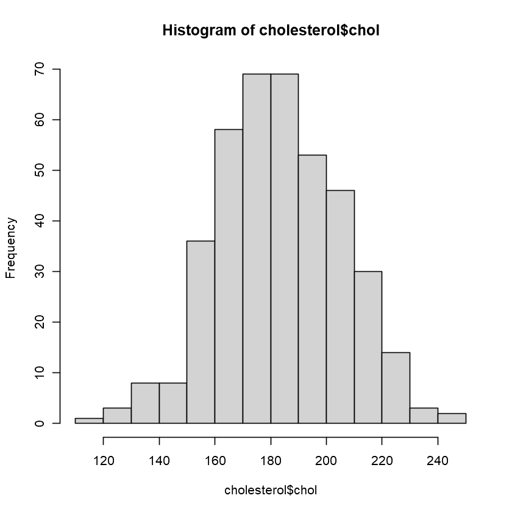

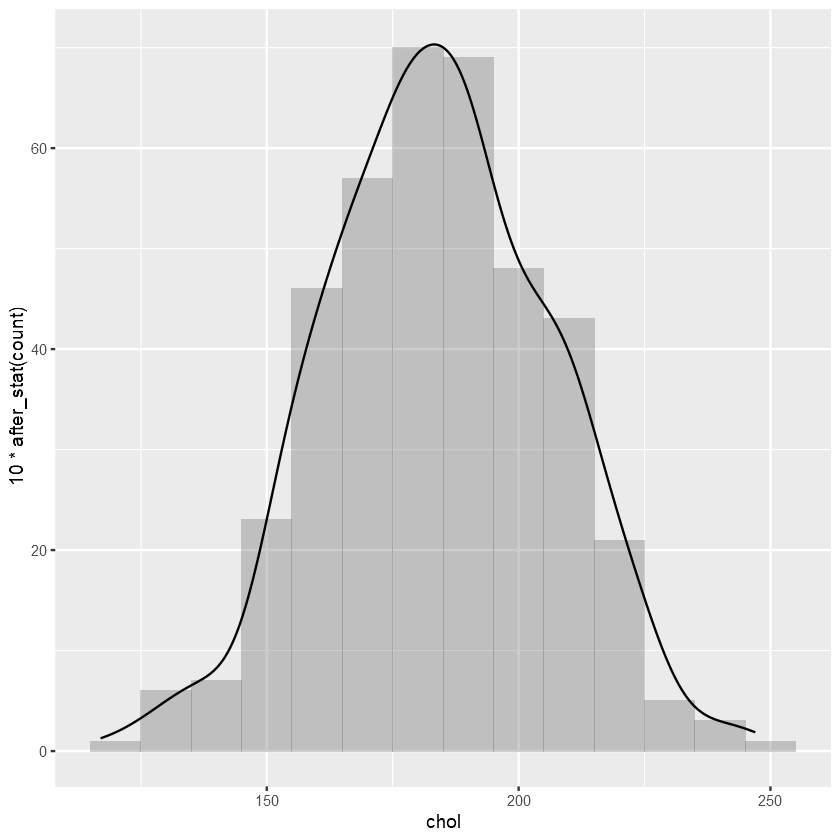

```r
# histogram 2 ways
# Using base R
hist(cholesterol$chol)

# Using ggplot, let's include a kernel density too
# 1. Data
ggplot(cholesterol) +
    # 2. Aesthetics
    aes(chol) + # Subtract the mean from each value to centre the distribution around 0
    # 4. Geoms
    geom_histogram(binwidth=10, alpha = 0.3) +
    geom_density(aes(y=10*after_stat(count))) # Use a kernel density estimate
    # after_stat will scale the y-axis of the geom
```

### 1.2.3 Quantile-quantile plots

**What is a quantile-quantile plot (Q-Q plot)?**

It's a scatter plot. More specifically, it's a scatter plot of your values (sorted in ascending order) against a sample size-matched number of **quantiles** from a chosen theoretical distribution. There are multiple ways to generate a Q-Q plot in R but here we will use:

- `qqnorm()` to check our data against a normal distribution and
- `qqline()` to draw a line going through the first and third quartile

**What do we want to see?**

Essentially a straight line. Depending on the shape and tails, you may need to **transform** your data to match a normal distribution. If that doesn't seem possible, then you really should not continue with a parametric test like the t-test.

**More about Q-Q plots:** There are many different distributions that can be identified by the outline of their Q-Q plot and recognizing these can help you decide if you need to take further steps to transform your data (See the Appendix for more details). You can also visit some helpful posts from [around](https://stats.stackexchange.com/questions/101274/how-to-interpret-a-qq-plot) the [web](https://data.library.virginia.edu/understanding-q-q-plots/) to help clarify these ideas.

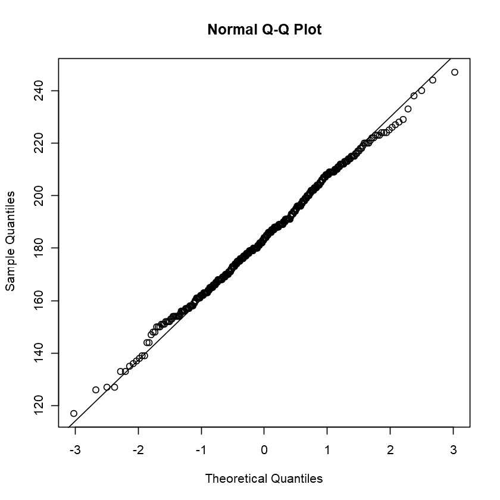

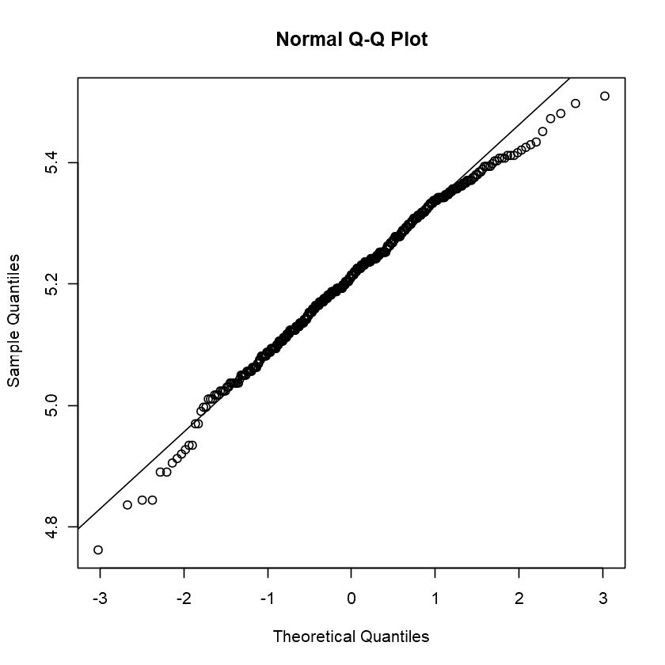

```r
# qqplot with a qqline

qqnorm(cholesterol$chol); qqline(cholesterol$chol)

# log transform your data

qqnorm(log(cholesterol$chol)); qqline(log(cholesterol$chol))
```

### 1.2.4 Homoscedasticity looks at the variance of "noise" in our data

Also written as **homoskedasticity** it relates to the variance within each group. When we generate a regression model, is the residual or error term constant? If the error term differs significantly across independent variables (ie `age_group`) then the model is missing a large effect from another independent variable.

We'll use Bartlett's test with `bartlett.test()` which essentially tests if *k* groups have equal variances and returns a K-squared value and p-value against our null hypothesis ($H_0$ = the groups have the same variance). A p-value less than our alpha level (ie 0.05) means we reject the null hypothesis. The call we will use takes the form:

```
    bartlett.test(formula = values ~ grouping, data = dataset)
```

where `values ~ grouping` means to use the data from the variable `values` and to group it by `grouping` when retrieving from `dataset`. This kind of syntax may feel familiar to our `facet_*()` layers when using `ggplot`.

Afterwards, we will compare the output of our test against a $\chi^{2}$ value with probability $$p = (1-\alpha)$$ where $\alpha$ represents our alpha level and the degrees of freedom is calculated as $$df = k-1$$ We will use the `qchisq(p, df)` function to generate this value. A K-squared value < Chi-squared result means we fail to reject our $H_0$.

**A quick warning**: this test assumes normality for your samples - if this is not the case, a rejection of $H_0$ may be a rejection of normality instead!

```r
## Bartlett's H0: There is homoskedasticity between samples cholesterol of age groups
bartlett.test(chol ~ age_group, data=cholesterol)

#equivalent to
bartlett.test(cholesterol$chol, cholesterol$age_group)

# If Chi-squared > Bartlett's K-squared, then data are homoskedastic (does not reject H0)
qchisq(p = 0.950, df = 1)
```

```
	Bartlett test of homogeneity of variances

data:  chol by age_group
Bartlett's K-squared = 2.7431, df = 1, p-value = 0.09767
```

```
	Bartlett test of homogeneity of variances

data:  cholesterol$chol and cholesterol$age_group
Bartlett's K-squared = 2.7431, df = 1, p-value = 0.09767
```

3.84145882069412

According to the Bartlett test, we can see that our two groups are homoscedastic since K-squared < $\chi^{2}$.

## 1.3.0 Visualize our groups of data further by boxplot

In our case, from testing above, the data follows a normal distribution and although the variance between groups is not exactly identical, it is still homoscedastic! Note that the p-value (0.09767) does not meet our alpha level for rejecting $H_0$ and our K-squared value (2.7431) < our Chi-squared result (3.8414).

We can now use a boxplot to look at the distribution of cholesterol for our 2 groups. Boxplots are a great way to visualize summary statistics for your data. Recall that:

- The thick line in the center of the box is the median.
- The upper and lower ends of the box are the first and third quartiles (or 25th and 75th percentiles) of your data.
- The whiskers extend from the 1st and 3rd quartiles to the closest values that are no further than **1.5*IQR** (inter-quartile range - the distance between the first and third quartiles).
- Data beyond these whiskers are considered outliers and plotted as individual points.

This visual method is a quick way to see how comparable your samples or groups are.

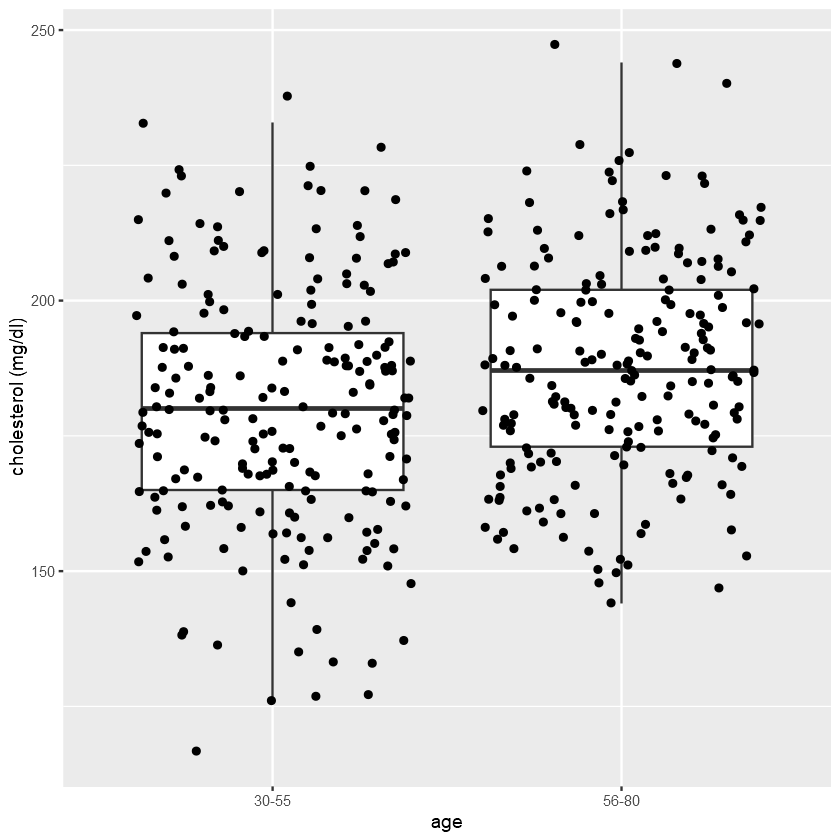

```r
# 1. Data
ggplot(cholesterol) +
    # 2. Aesthetics
    aes(x = factor(age_group), y = chol) +
    xlab("age") +
    ylab("cholesterol (mg/dl)") +
    # 3. Scaling
    scale_x_discrete(labels = c("30-55", "56-80")) +
    # 4. Geoms
    geom_boxplot(outlier.shape = NA) +
    geom_jitter()
```

## 1.4.0 Finally, a t-test to compare our distributions

There seems to be a lot of overlap in our cholesterol values. How do we tell if the means are truly different?

Let's think about this a little more explicitly:

The **null hypothesis ($H_0$)** is that there is no difference in the sample means between our groups.

An **alternative hypothesis ($H_1$)** is that there is a difference between the means (2-sided test), or that the difference in means is greater or lesser than zero (1-sided test).

| Decide on your $\alpha$ **before** you conduct your study and collect data |
| --- |

$\alpha$ is our p-value, and $\mu$ is the population mean, **k** is our sample mean. Remember that we are *estimating* the true population mean using the sample that we have. Our **p-value** is the probability of finding our observed value by chance given that the null hypothesis is true.

We will use a simple **Student's t-test** to test the alternative hypothesis that the true difference in means is not equal to 0.

You can alternatively enter your variables in a `formula`, in this case `y ~ x`. The `~` in r language is used to separate the left and right sides of a formula. (You can run a 1-sided t-test by specifying `alternative = 'greater'` or `alternative = 'less'`). In this case, `alternative = 'two-sided'` and `conf.level = 0.95` are the default parameters and only included for clarity. For now we are assuming that equal variance is true based on our previous tests.

```r
#?t.test

# Provide t.test with the two groups of data to compare
t.test(x = cholesterol$chol[cholesterol$age_group == 0], # 55 years or younger
       y = cholesterol$chol[cholesterol$age_group == 1], # 56 years or older
       alternative = "two.sided", conf.level = 0.95, var.equal = TRUE)
```

```
	Two Sample t-test

data:  cholesterol$chol[cholesterol$age_group == 0] and cholesterol$chol[cholesterol$age_group == 1]
t = -3.6349, df = 398, p-value = 0.0003146
alternative hypothesis: true difference in means is not equal to 0
95 percent confidence interval:
 -12.202574  -3.636122
sample estimates:
mean of x mean of y
 179.9751  187.8945
```

```r
#is equivalent to
t.test(formula = chol ~ age_group, data = cholesterol, var.equal = TRUE)

# Much less code to write as well!
```

```
	Two Sample t-test

data:  chol by age_group
t = -3.6349, df = 398, p-value = 0.0003146
alternative hypothesis: true difference in means is not equal to 0
95 percent confidence interval:
 -12.202574  -3.636122
sample estimates:
mean in group 0 mean in group 1
       179.9751        187.8945
```

### 1.4.1 Interpreting our t-test

Our output tells us that the mean cholesterol ($\mu$) for those aged 30-55 is 179.98 mg/dl and the mean for those aged 56-80 is 187.89 mg/dl. The difference in means is significant at a p-value of 0.0003146 (< 0.05).

We now know that based on our binning, there is a positive relationship between cholesterol and age. However the t-test has limitations. What is the magnitude of this relationship during aging? Does it change by approximately the same amount per year? What if we don't want to break our data into groups?

For the answer to this, we'll need to open a new toolset.

**Comprehension Question 1.0.0** Reflect on the methods we've discussed to determine if our data set has a normal distribution. Which of these is best, and which should we use first?

**Follow-up question:** why do we even care about our data having a normal distribution?

## Comprehension Question 1.0.0 Answer:

# 2.0.0 Linear regression models of our dataset

| Source: "All (or most) of statistics". Bolker, 2007. |
| --- |

## 2.1.0 Assumptions of general linear models

1. **Observed values are independent of each other (*independence*)**

- The probability of an event occurring does not affect the probability of another event occurring.

2. **Variation around expected values (*residuals*) are normally distributed (*normality*)**

| Source: "An Introduction to Statistical Learning". James et al., 2017. |
| --- |

| While we may think our data as a line, if we sampled many values at the same x predictor, these values should distribute normally around the y-axis. |
| --- |

**What is a residual?** We often see the word *residuals* thrown around, especially when looking at the analysis of variance. Residuals are the difference between our measured value and the expected value of Y given any value X. How do we calculate the difference from our **expected values**? For our purposes, we can use the words **residuals** and **error** interchangebly to correspond to the difference between our measured values and the *sample mean for any Y|X*.

The meaning of residuals can change slightly when we think about linear models of regression since we are generating "predicted" values based on a model formula rather than simply the mean of a population. In that case our residuals is calculated as **residual = (observed - expected)** (see Section **2.3.1**)

3. **Constant variance, homoscedastic (equal variance)**

- it follows from above that *even though your residuals may be normally distributed* at specific values of x, they **must also share the same variance for those distributions** as well.

| For values of X, values of Y must show equal variance. If you see a funnel or tornado shape, you may have to reconsider some things. |
| --- |

4. **Observed values (y) are related by linear functions of the parameters to x (*linearity*)**

- Example: For $y = a + b_1x+b_2x^2$, the parameters a, b<sub>1</sub>, and b<sub>2</sub> are linear even though the independent variable has a quadratic component, $x^2$. However, $y = ax^b$ is nonlinear with respect to the parameter b, and is not suitable for linear regression.

Assumptions 2 and 3 are often grouped together.

**Watch out for normality!** It is often confusing when we use the words **normally distributed** with our data for general linear models. Assumption 2 requires that our *residuals* are normally distributed BUT it *does not require* that our raw data have a normal distribution. Remember you are trying to model outcomes based across a spectrum of predictor values which can span an unknown range.  
In fact, there are studies to support that ANOVA remains quite robust [even in the face of even non-normal distributions](https://econtent.hogrefe.com/doi/abs/10.1027/1614-2241/a000016)! However, to be sure of your results, it is best to follow the prerequisite requirements of ANOVA when possible.

## 2.2.0 Linear Models

For **simple linear regression** we are modeling a continuous outcome by a single continuous variable. **Example**: modeling cholesterol using BMI.

For **multiple linear regression** we are modeling a continuous outcome by more than one continuous variable. **Example**: modeling cholesterol using BMI *and* age. In this case, we must consider whether there is an *interaction* between age and BMI on cholesterol (more on interactions to follow).

For **one-way** **ANOVA** (**AN**alysis **O**f **VA**riance) we are modeling a continuous outcome by a single categorical variable. **Example**: modeling cholesterol by sex. It is important that categorical variables are explicitly input as factors to be interpreted properly in the model. For example, since we have encoded sex as 0 and 1 (instead of 'M' and 'F'), we need to specify that sex is to be treated as ordinal and not as a number. Therefore we specify sex as a factor of 2 levels, 0 and 1.

For **multi-way** **ANOVA** we are modeling a continuous outcome by more than one categorical variable. **Example**: modeling cholesterol by sex **and** APOE genetic variants. Again, we need to consider any interaction between our categorical variables, and we need to specify our numeric values to be treated as categorical variables and not numbers. APOE will be a factor of 6 levels, one for each genetic variant.

Lastly, for **ANCOVA** (**AN**alysis of **COVA**riance) we are modeling a continuous outcome by a *combination* of categorical **AND** continuous variables. **Example**: modeling cholesterol using the genetic variants of APOE and BMI. Again, our categorical variable must be input as a factor. ANCOVA allows for each group (each genetic variant of APOE in this example) to have a separate slope.

This is a summary table you might find helpful for choosing a model based on the data types you have, and the assumptions you are making. I hope to show that model selection is akin to going through mental checklist for your data, and not that scary.

| model | categorical | continuous | linearity | normality | homoscedasticity |
| --- | --- | --- | --- | --- | --- |
| simple linear regression | X | $\checkmark$ | $\checkmark$ | $\checkmark$ | $\checkmark$ |
| multiple linear regression | X | $\checkmark\checkmark$ | $\checkmark$ | $\checkmark$ | $\checkmark$ |
| one-way analysis of variance (ANOVA) | $\checkmark$ | X | $\checkmark$ | $\checkmark$ | $\checkmark$ |
| multi-way ANOVA | $\checkmark\checkmark$ | X | $\checkmark$ | $\checkmark$ | $\checkmark$ |
| analysis of covariance (ANCOVA) | $\checkmark$ | $\checkmark$ | $\checkmark$ | $\checkmark$ | $\checkmark$ |
| nonlinear least squares | X | $\checkmark$ | X | $\checkmark$ | $\checkmark$ |
| nonlinear ANCOVA | $\checkmark$ | $\checkmark$ | X | $\checkmark$ | $\checkmark$ |
| generalized linear models | $\checkmark$ | $\checkmark$ | X* | X | X |

*restricted cases

**Note**: the independence assumption is required for all the models below, and is not included in the chart for spacing reasons.

### 2.2.1 Revisiting our question

**What is the *relationship* between cholesterol and age?**

Now, we can pick a model to answer our question by considering the assumptions above *instead* of a t-test.

If we evaluate our independent and dependent variables, **age** and **cholesterol**, they are both *continuous*, not *categorical*. We only have one independent variable. From the plot we made earlier (repeated below) it looks like if there is a relationship between age and cholesterol it would be linear.

1. The values are independent (from separate blood draws).
2. Data points have an even spread so the residual variance is likely equal and normally distributed.

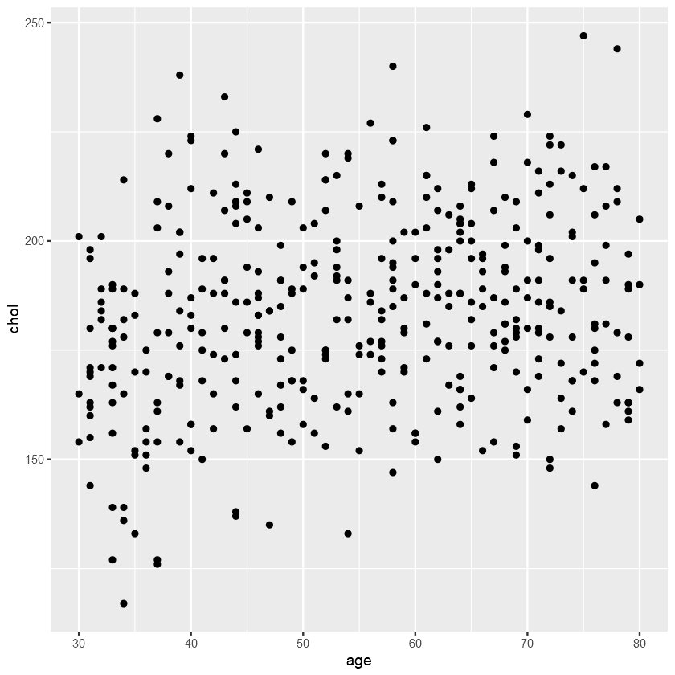

```r
# Show a scatterplot again of age vs cholestorol
# 1. Data
ggplot(cholesterol) +
    # 2. Aesthetics
    aes(x = age, y = chol) +
    # 4. Geoms
    geom_point()
```

Based on the above criteria, we will try using a simple linear regression to test the association between mean serum cholesterol and age.

## 2.3.0 Simple linear regression made simple with `ggplot()`

What we are looking for, is the slope of the line relating cholesterol to age, which will tell us the magnitude and direction of the relationship between these variables. We can look at the slope for the linear model that `ggplot()` would fit for us to get an idea of what our model will look like.

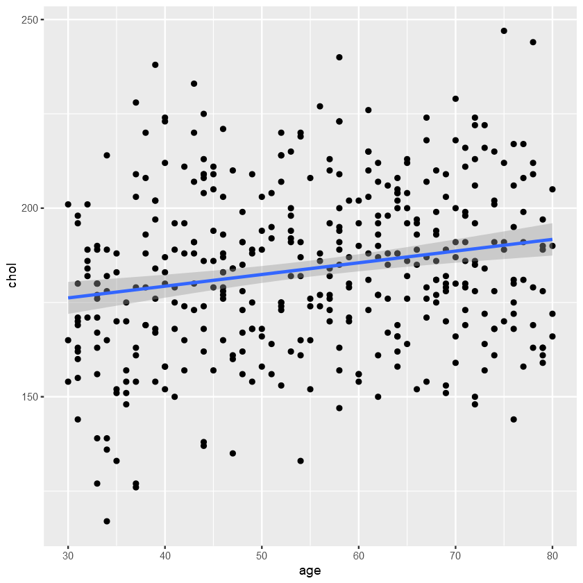

```r
# 1. Data
ggplot(cholesterol) +
    # 2. Aesthetics
    aes(x = age, y = chol) +
    # 4. Geoms
    geom_point() +
    stat_smooth(method = "lm") # Add a stat_smooth as we've seen in the past
```

### 2.3.1 Review: the equation for a straight line.

To make sense of what we're seeing on our plot, let's review the equation for a straight line:

\begin{equation*}\Large Y \sim Normal(a + bx, {\sigma^2}) \end{equation*}

$Y$ is our dependent variable that we are attempting to model.  
$x$ is our independent variable.  
$a$ is the intercept (the value of $Y$ where $x$ = 0; where x crosses the y-axis).  
$b$ is the slope of the line (the change in $Y$ corresponding to a unit increase in $x$).  
$Normal$ is telling us that our error is normally distributed.  
$\sigma^2$ is the variance (squared deviation of the variable x from its mean)

**Slopes**

- A flat line ($b$ = 0) would mean that there is no association between $x$ and $Y$.
- The above example has a positive slope, meaning that $Y$ increases as values of $x$ increase.
- With a negative slope, $Y$ decreases as values of $x$ increase.

The **interpretation** in our example is that the slope is the difference in mean serum cholesterol associated with a one year increase in age.

With a straight line we are not, of course, plotting through all of our points, but rather close to the mean of an outcome in y as a function of x. For example, there are only six values of cholesterol for the 50 year-old age group, and our line will fall somewhere close to the mean of these values. Values of $Y$ have a distribution at a given $x$, which we have assumed is normally distributed.

Lastly, in this equation we also have some normally distributed error. Sampling error exists in our estimates because different estimates give different means.

How do we actually find the best fitting line? We use **least squares estimation**, which minimizes the sum of squares of the vertical distances from the observed points to the least squares regression line ($y -\hat{y}$)<sup>2</sup> .

$y$ - observed value  
$\hat{y}$ - estimated value  
$\bar{y}$ - sample mean

| A least squares estimation attempts to minimize overall distance of observed y-values from the estimated y-values for a predictor x within our model |
| --- |

### 2.3.2 Use the `lm()` function to generate a linear model

Let's run this simple linear regression. Using R, the intercept and slope terms are implicit. We'll use the `lm()` function which will produce output but the results can also be saved as a list object with all of the information about the model. For now, `lm()` function has 2 parameters we are most interested in:

- `formula`: takes in an equation expression that defines our linear model.
- `dataset`: the dataset where our values for regression will be found.

In R, a formula takes on the form of `y ~ x`. As we are used to writing equations, our dependent variable (cholesterol) is on the left side of `~` and our independent variable (age) is on the right side. The tilde `~` separates these sides and is actually the key identifier in a formula. This allows R to pass the variable (x and y) information along without evaluating them so that the function *receiving* the data [can do the evaluating](https://www.datacamp.com/tutorial/r-formula-tutorial)

**Setting your y-intercept to 0!** There are times when the intercept, the value of y at x = 0, doesn't make much intuitive sense to interpret our data. To force the intercept to zero (y = bx) to have relative comparisons instead, use **lm(y ~ 0 + x)**. Adding the 0 term, forces the model to have a y-intercept through 0.

Let's investigate creating a linear model for explaining the relationship between cholesterol and age.

```r
# Generating a linear model. Looks a lot like the bartlett.test() format right?
lm(formula = chol ~ age, data = cholesterol)
```

```
Call:
lm(formula = chol ~ age, data = cholesterol)

Coefficients:
(Intercept)          age
   166.9017       0.3103
```

The function will output our formula, the slope and the intercept. However, if we save the output of the function into an object, `ageFit`, we get a `list` object of the model, the input, and all associated statistics.

```r
# Assign the linear model to an object
ageFit <- lm(formula = chol ~ age, data = cholesterol)

# ageFit is a list of 12 elements that can be individually accessed by using the dollar operator
str(ageFit, give.attr = FALSE)
```

```
List of 12
 $ coefficients : Named num [1:2] 166.9 0.31
 $ residuals    : Named num [1:400] 25.13 21.27 18.24 4.55 -8.04 ...
 $ effects      : Named num [1:400] -3678.3 89.45 17.61 1.86 -9.49 ...
 $ rank         : int 2
 $ fitted.values: Named num [1:400] 190 183 187 177 183 ...
 $ assign       : int [1:2] 0 1
 $ qr           :List of 5
  ..$ qr   : num [1:400, 1:2] -20 0.05 0.05 0.05 0.05 0.05 0.05 0.05 0.05 0.05 ...
  ..$ qraux: num [1:2] 1.05 1.02
  ..$ pivot: int [1:2] 1 2
  ..$ tol  : num 1e-07
  ..$ rank : int 2
 $ df.residual  : int 398
 $ xlevels      : Named list()
 $ call         : language lm(formula = chol ~ age, data = cholesterol)
 $ terms        :Classes 'terms', 'formula'  language chol ~ age
 $ model        :'data.frame':	400 obs. of  2 variables:
  ..$ chol: int [1:400] 215 204 205 182 175 176 159 169 175 189 ...
  ..$ age : int [1:400] 74 51 64 34 52 39 79 38 52 58 ...
```

### 2.3.3 Use `summary()` to look at the salient information about your model

As you can see from looking at the structure, the `lm` model object holds a lot of information. We can use the `summary()` function to pull out some of the more important information about our model instead of wading through all of the data. The `summary()` function can give us residuals, errors, p-values and more in addition to our coefficients.

It should be noted, that this information can vary between different types of objects as well.

```r
# Look at the summary information of 'fit'
summary(ageFit)
```

```
Call:
lm(formula = chol ~ age, data = cholesterol)

Residuals:
    Min      1Q  Median      3Q     Max
-60.453 -14.643  -0.022  14.659  58.995

Coefficients:
             Estimate Std. Error t value Pr(>|t|)
(Intercept) 166.90168    4.26488  39.134  < 2e-16 ***
age           0.31033    0.07524   4.125 4.52e-05 ***
---
Signif. codes:  0 '***' 0.001 '**' 0.01 '*' 0.05 '.' 0.1 ' ' 1

Residual standard error: 21.69 on 398 degrees of freedom
Multiple R-squared:  0.04099,	Adjusted R-squared:  0.03858
F-statistic: 17.01 on 1 and 398 DF,  p-value: 4.522e-05
```

### 2.3.4 Interpreting our linear model

The intercept is 166.9 and the slope is 0.31. What does that actually mean? It means a baby (age 0 or 0 years) would be expected to have on average a serum cholesterol of 166.9 mg/dl. For every yearly increase in age, mean serum cholesterol is expected to increase by 0.31 mg/dl. These results are significant with a p-value < 0.001 (4.52<sup>-05</sup>). We can reject the null hypothesis and say that mean serum cholesterol is significantly higher in older individuals. The Adjusted R-squared value (which accounts for model complexity) tells us that about 4% (0.03858) of the variability in cholesterol is explained by age.

Note there are two sets of p-values presented: `Pr(>|t|)`, and a `p-value` associated with the F-statistic.

- `Pr(>|t|)` is an evaluation of the co-effiecient producing this t-statistic against a null hypothesis in which the true co-efficient is 0. In other words, looking at the intercept of 166.90, it is the proportion of the t-distribution at df = 398 which is greater than the absolute value of your t statistic (39.134).
- `p-value` tells us about the model overall and whether it is predicting better than just random noise. You'll notice that in the case of a single continuous predictor, we get the same p-value as Pr(>|t|) for the age variable. We will discuss F-values a little more in just a few sections.

### 2.3.5 Use `confint()` to generate confidence intervals on your data

Given that we have a model object like our `ageFit` linear model, we can generate a confidence interval using the `confint()` method. By default this function sets the argument `level` to 0.95 or a 95% confidence interval level. Let's generate a confidence interval for our model parameters.

```r
# Generate a confidence interval with confint()
confint(ageFit)
```

A matrix: 2 × 2 of type dbl

|  | 2.5 % | 97.5 % |
| --- | --- | --- |
| (Intercept) | 158.5171656 | 175.2861949 |
| age | 0.1624211 | 0.4582481 |

We can further get confidence intervals for these values to say that in 95% of chosen intervals (ie 158.5-175.3 mg/dl in this case) the mean cholesterol of a baby will fall within that interval, or that we are 95% confident that the difference in mean cholesterol associated with a one year increase in age is between 0.16 and 0.46 mg/dl.

**Be precise about confidence Intervals!** Just a reminder that a 95% confidence interval **does not** mean there is a 95% probability that the true population value (ie mean) lies between our range. We don't know the true population value or how close it is to our estimated value. We know with 100% certainty that it is either inside or outside the interval.

More precisely, the correct interpretation is that if we were to randomly sample from our population *multiple times*, we expect that 95% of our constructed intervals would contain the true population value! Therefore we *can* say with 95% certainty that our calculated interval contains the true population value. It's a very fine distinction.

On the bright side, we can also note that a wide interval suggests a less precise estimate vs a small interval. Of course the size of our interval is influenced by our sample size with narrower intervals generated by higher sample numbers. Likewise, using a smaller confidence value (ie 90%) produces a smaller interval as well.

| It can be hard to be confident with the definition of a confidence interval. |
| --- |

## 2.4.0 Multiple linear regression

In multiple linear regression we use multiple continuous dependent variables to predict outcome values. Additional terms can be added in 2 ways.

### 2.4.1 Adding powers of a variable (polynomial regression)

It was mentioned before that the 'linear' part of linear regression is the linear function of the *parameters* and not the independent variables. In the example below, the parameters $a$, $b_1$, and $b_2$ are linear even though the independent variable has a quadratic component, $x^2$. An example of this could be synthesizing a chemical, where with increasing temperature, synthesis progresses with an increasing curve.

*Expression:*

\begin{equation*}\Large Y \sim Normal(a + b_1x + b_2x^2, {\sigma^2}) \end{equation*}

If we were to write this in R, again our intercept and coefficients are implicit. To write the quadratic term we use the function `I()` which just means 'as.is'. This allows the interpreter to see the `^` as a power symbol and not as an interaction term.

*R code:*

`lm(y ~ x + I(x^2))`

Suppose from our data that we think cholesterol can be modeled by age as a quadratic equation. What would that look like?

```r
# summarize the results of a multiple linear regression
summary(lm(chol ~ age + I(age^2), data = cholesterol))
```

```
Call:
lm(formula = chol ~ age + I(age^2), data = cholesterol)

Residuals:
    Min      1Q  Median      3Q     Max
-56.836 -15.063  -0.654  14.534  60.246

Coefficients:
              Estimate Std. Error t value Pr(>|t|)
(Intercept) 120.890937  16.722415   7.229 2.51e-12 ***
age           2.120309   0.640815   3.309  0.00102 **
I(age^2)     -0.016562   0.005824  -2.844  0.00469 **
---
Signif. codes:  0 '***' 0.001 '**' 0.01 '*' 0.05 '.' 0.1 ' ' 1

Residual standard error: 21.5 on 397 degrees of freedom
Multiple R-squared:  0.06014,	Adjusted R-squared:  0.05541
F-statistic:  12.7 on 2 and 397 DF,  p-value: 4.498e-06
```

It looks like this modification to our model explains our model's variation (Adjusted R-squared) slighlty more but doesn't drastically improve on it.

### 2.4.2 Adding extra continuous variables to our model

We are interested in improving our model by adding an extra variable we think might have an effect on our outcome values. In the example below, we are adding the independent variables x<sub>1</sub>, x<sub>2</sub>, and each of these terms has their own linear parameter b<sub>1</sub> and b<sub>2</sub>, respectively.

*Expression:*

\begin{equation*}\Large Y \sim Normal(a + b_1x_1 + b_2x_2, {\sigma^2}) \end{equation*}

This is the model we will be using next. To aid with interpretation let's think about a parameter. b<sub>2</sub> is the expected mean change in unit per change in x<sub>2</sub> if x<sub>1</sub> is held constant (sometimes called controlling for x<sub>1</sub>).

The null hypothesis in this case is that all b<sub>1</sub>, b<sub>2</sub> = 0. The alternative hypothesis is that at least one of these parameters is not null.

Again in R the intercept and coefficients are implicit in the the `lm` function.

*R code:*

`lm(y ~ x1 + x2)`

We know that age has an effect on cholesterol. With our new model we want to ask the question: **Is there a statistically significant relationship between mean serum cholesterol and age after controlling for BMI?** Let's look graphically at these relationships to help us understand our model. First let's plot BMI vs cholesterol. We can add a linear fit to make sure we are expecting a positive slope.

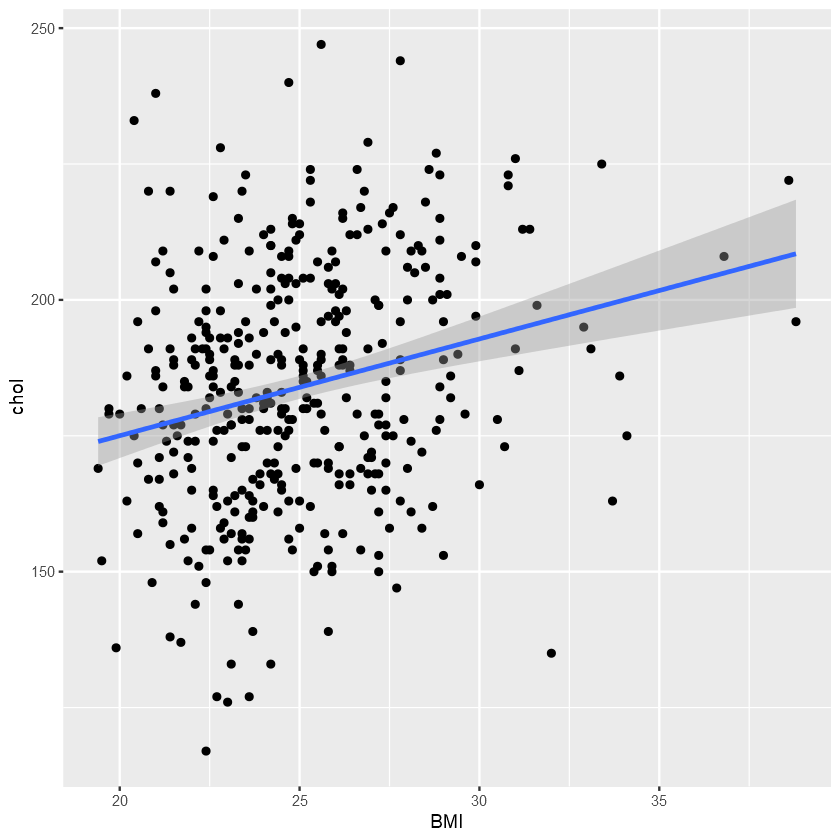

```r
# Plot the relationship between cholesterol and BMI
# 1. Data
ggplot(cholesterol) +
    # 2. Aesthetics
    aes(x = BMI, y = chol) + # Use BMI as the x-value
    # 4. Geoms
    geom_point() +
    stat_smooth(method = "lm")
```

We should also take a look at the relationship between BMI and age.

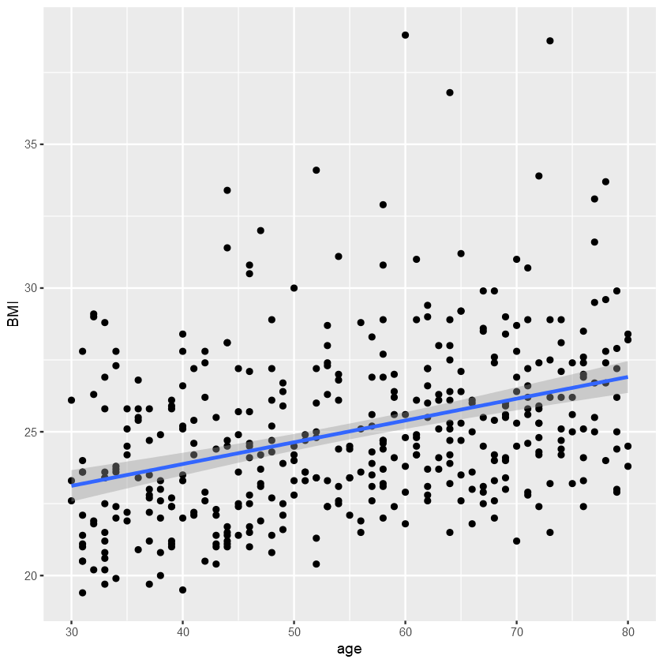

```r
# Plot the relationship between age and BMI
# 1. Data
ggplot(cholesterol) +
    # 2. Aesthetics
    aes(x = age, y = BMI) + # Use age as the x-value, BMI as the y-value
    # 4. Geoms
    geom_point() +
    stat_smooth(method = "lm")
```